# Exploratory analysis of RNAseq data

Hugo Tavares

30 November 2018

# Exploring expression value distributions

We will start our data exploration by understanding how our expression data are distributed. We will do this using frequency polygons (similar to histograms) for our expression data found in the `norm_cts` object.

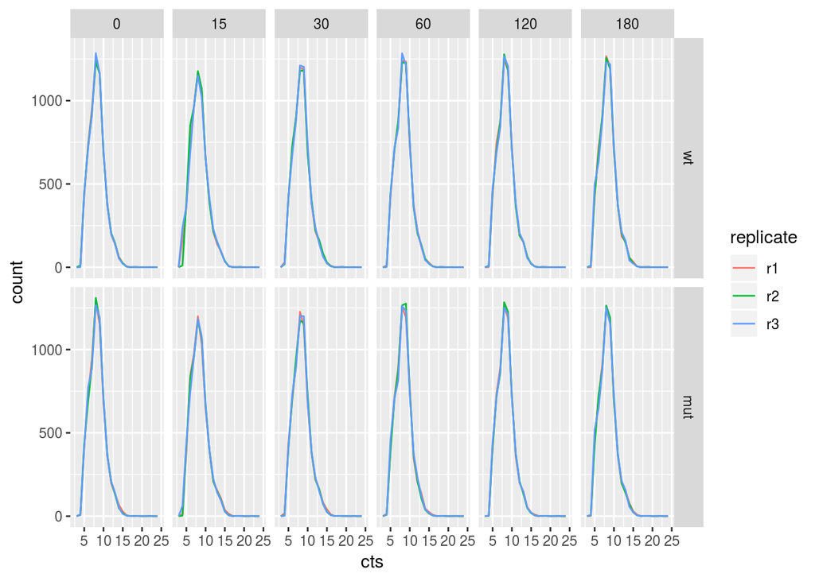

To produce the plot above, we need to do a few things:

1. Convert the matrix of normalised counts to a `tibble` object
2. Convert that table to “long” format, i.e. with 3 columns: `gene`, `sample_id`, `cts`, rather than one column per sample
3. Join this table with the `sample_info` table

### Matrix object

You might have noticed that `norm_cts` is a `matrix` object. We haven’t found these before, and to produce either plot, it is convenient to start by converting our matrix of gene expression to a `tibble` (`data.frame`).

Matrices are a bit similar to `data.frame`, but they only contain values of a single type, in this case numeric values (whereas in a `data.frame` different columns can contain different types of data).

```r
# Look at the first 10 rows and first 5 samples of norm_cts
norm_cts[1:10, 1:5]
```

```
##              wt_0_r1  wt_0_r2  wt_0_r3 wt_15_r1 wt_15_r2
## SPAC212.11  4.947329 4.969572 5.657995 5.452545 5.444799
## SPAC212.09c 5.443589 6.205209 6.172470 5.943911 6.333457
## SPAC212.04c 5.751174 5.058125 5.544557 5.675589 5.175381
## SPNCRNA.601 5.731843 4.868198 4.936256 5.569892 5.319763
## SPAC977.11  7.046601 6.837324 6.788719 6.870560 6.092104
## SPAC977.13c 5.335904 5.339053 5.310125 5.319716 5.988160
## SPAC977.15  6.500652 6.232901 6.697946 7.028231 6.923664
## SPAC977.16c 7.237060 7.457934 7.475547 7.088272 7.461087
## SPNCRNA.607 5.961123 5.691651 5.942602 5.923746 5.874517
## SPAC1F8.06  6.640223 6.651266 6.777698 4.616742 5.607453
```

You will also notice that gene names are contained in the row names of this matrix.

To convert this matrix into a `tibble` object we can use the function `as_tibble()`:

```r
# Convert matrix to tibble
as_tibble(norm_cts)
```

```
## # A tibble: 6,011 x 36
##    wt_0_r1 wt_0_r2 wt_0_r3 wt_15_r1 wt_15_r2 wt_15_r3 wt_30_r1 wt_30_r2
##      <dbl>   <dbl>   <dbl>    <dbl>    <dbl>    <dbl>    <dbl>    <dbl>
##  1    4.95    4.97    5.66     5.45     5.44     6.50     5.08     5.25
##  2    5.44    6.21    6.17     5.94     6.33     6.41     6.71     7.15
##  3    5.75    5.06    5.54     5.68     5.18     5.10     5.82     6.31
##  4    5.73    4.87    4.94     5.57     5.32     4.20     5.17     4.77
##  5    7.05    6.84    6.79     6.87     6.09     6.19     6.91     6.66
##  6    5.34    5.34    5.31     5.32     5.99     5.30     7.61     7.48
##  7    6.50    6.23    6.70     7.03     6.92     7.53     6.44     6.68
##  8    7.24    7.46    7.48     7.09     7.46     7.65     6.88     7.13
##  9    5.96    5.69    5.94     5.92     5.87     4.84     7.38     7.30
## 10    6.64    6.65    6.78     4.62     5.61     6.15     5.66     6.50
## # ... with 6,001 more rows, and 28 more variables: wt_30_r3 <dbl>,
## #   wt_60_r1 <dbl>, wt_60_r2 <dbl>, wt_60_r3 <dbl>, wt_120_r1 <dbl>,
## #   wt_120_r2 <dbl>, wt_120_r3 <dbl>, wt_180_r1 <dbl>, wt_180_r2 <dbl>,
## #   wt_180_r3 <dbl>, mut_0_r1 <dbl>, mut_0_r2 <dbl>, mut_0_r3 <dbl>,
## #   mut_15_r1 <dbl>, mut_15_r2 <dbl>, mut_15_r3 <dbl>, mut_30_r1 <dbl>,
## #   mut_30_r2 <dbl>, mut_30_r3 <dbl>, mut_60_r1 <dbl>, mut_60_r2 <dbl>,
## #   mut_60_r3 <dbl>, mut_120_r1 <dbl>, mut_120_r2 <dbl>, mut_120_r3 <dbl>,
## #   mut_180_r1 <dbl>, mut_180_r2 <dbl>, mut_180_r3 <dbl>
```

But now we’ve lost our gene names! If we look at the function’s help (`?as_tibble`), we can see that there’s a way to solve this problem:

```r
# Convert matrix to tibble - add colnames to a new column called "gene"
norm_cts_tbl <- as_tibble(norm_cts, rownames = "gene")
norm_cts_tbl
```

```
## # A tibble: 6,011 x 37
##    gene  wt_0_r1 wt_0_r2 wt_0_r3 wt_15_r1 wt_15_r2 wt_15_r3 wt_30_r1
##    <chr>   <dbl>   <dbl>   <dbl>    <dbl>    <dbl>    <dbl>    <dbl>
##  1 SPAC…    4.95    4.97    5.66     5.45     5.44     6.50     5.08
##  2 SPAC…    5.44    6.21    6.17     5.94     6.33     6.41     6.71
##  3 SPAC…    5.75    5.06    5.54     5.68     5.18     5.10     5.82
##  4 SPNC…    5.73    4.87    4.94     5.57     5.32     4.20     5.17
##  5 SPAC…    7.05    6.84    6.79     6.87     6.09     6.19     6.91
##  6 SPAC…    5.34    5.34    5.31     5.32     5.99     5.30     7.61
##  7 SPAC…    6.50    6.23    6.70     7.03     6.92     7.53     6.44
##  8 SPAC…    7.24    7.46    7.48     7.09     7.46     7.65     6.88
##  9 SPNC…    5.96    5.69    5.94     5.92     5.87     4.84     7.38
## 10 SPAC…    6.64    6.65    6.78     4.62     5.61     6.15     5.66
## # ... with 6,001 more rows, and 29 more variables: wt_30_r2 <dbl>,
## #   wt_30_r3 <dbl>, wt_60_r1 <dbl>, wt_60_r2 <dbl>, wt_60_r3 <dbl>,
## #   wt_120_r1 <dbl>, wt_120_r2 <dbl>, wt_120_r3 <dbl>, wt_180_r1 <dbl>,
## #   wt_180_r2 <dbl>, wt_180_r3 <dbl>, mut_0_r1 <dbl>, mut_0_r2 <dbl>,
## #   mut_0_r3 <dbl>, mut_15_r1 <dbl>, mut_15_r2 <dbl>, mut_15_r3 <dbl>,
## #   mut_30_r1 <dbl>, mut_30_r2 <dbl>, mut_30_r3 <dbl>, mut_60_r1 <dbl>,
## #   mut_60_r2 <dbl>, mut_60_r3 <dbl>, mut_120_r1 <dbl>, mut_120_r2 <dbl>,
## #   mut_120_r3 <dbl>, mut_180_r1 <dbl>, mut_180_r2 <dbl>, mut_180_r3 <dbl>
```

**Exercise:**

- Convert the `raw_cts` matrix to a tibble and save it into a new object called `raw_cts_tbl`

### Reshaping data to “long” format

There’s two functions that allow us to convert tables from a “wide” to a “long” format and vice-versa: `gather()` and `spread()`.

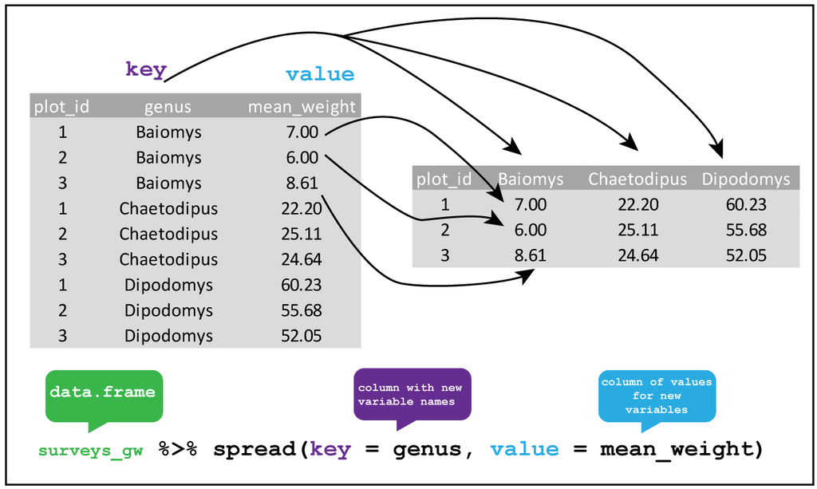

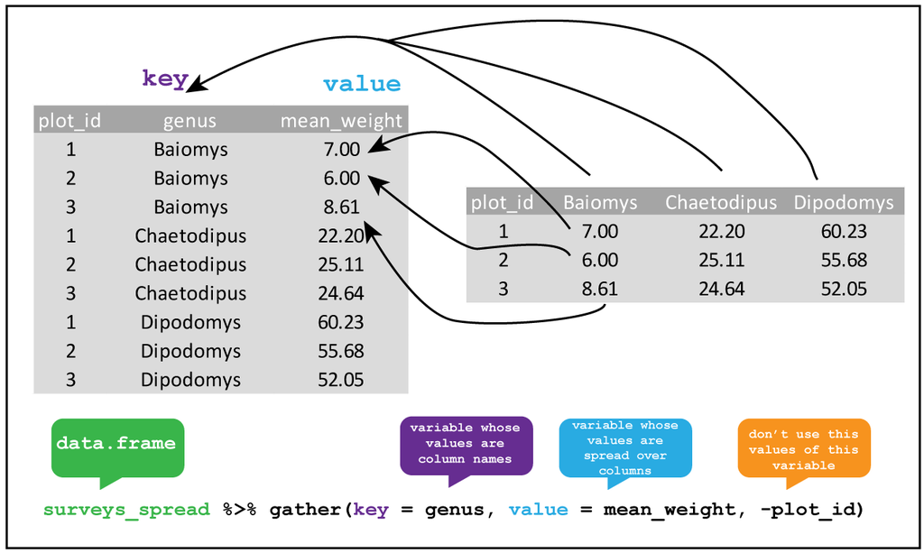

If you notice, what we want in our case is to `gather` our gene expression columns. We can do this by giving `gather()` four things:

- The data, i.e. our table of gene expression
- A name for the new column that will contain the old column names (the “key” column)
- A name for the new column that will contain our expression counts (the “values” column)
- The names of the columns that we want to gather in this way

Like so:

```r
# "gather" the counts data
norm_cts_long <- norm_cts_tbl %>%
  gather("sample", "cts", wt_0_r1:mut_180_r3)

norm_cts_long
```

```
## # A tibble: 216,396 x 3
##    gene        sample    cts
##    <chr>       <chr>   <dbl>
##  1 SPAC212.11  wt_0_r1  4.95
##  2 SPAC212.09c wt_0_r1  5.44
##  3 SPAC212.04c wt_0_r1  5.75
##  4 SPNCRNA.601 wt_0_r1  5.73
##  5 SPAC977.11  wt_0_r1  7.05
##  6 SPAC977.13c wt_0_r1  5.34
##  7 SPAC977.15  wt_0_r1  6.50
##  8 SPAC977.16c wt_0_r1  7.24
##  9 SPNCRNA.607 wt_0_r1  5.96
## 10 SPAC1F8.06  wt_0_r1  6.64
## # ... with 216,386 more rows
```

If we wanted to do the reverse, we could use the `spread()` function:

```r
norm_cts_long %>%
  spread(sample, cts)
```

```
## # A tibble: 6,011 x 37
##    gene  mut_0_r1 mut_0_r2 mut_0_r3 mut_120_r1 mut_120_r2 mut_120_r3
##    <chr>    <dbl>    <dbl>    <dbl>      <dbl>      <dbl>      <dbl>
##  1 SPAC…     5.47     5.50     5.48       5.60       5.25       5.26
##  2 SPAC…     6.67     6.61     7.03       6.82       7.05       6.90
##  3 SPAC…    10.9     10.8     10.9       10.9       10.9       11.0
##  4 SPAC…     8.02     8.06     7.88       8.03       7.87       7.84
##  5 SPAC…     7.68     7.62     7.44       7.77       7.65       7.79
##  6 SPAC…     8.69     8.92     8.64       8.33       8.62       8.27
##  7 SPAC…     8.38     8.32     8.23       8.46       8.41       8.49
##  8 SPAC…    12.1     12.0     11.9       11.5       11.5       11.6
##  9 SPAC…     7.73     8.01     7.74       7.71       7.69       7.73
## 10 SPAC…     8.03     8.08     8.35       8.35       8.41       8.64
## # ... with 6,001 more rows, and 30 more variables: mut_15_r1 <dbl>,
## #   mut_15_r2 <dbl>, mut_15_r3 <dbl>, mut_180_r1 <dbl>, mut_180_r2 <dbl>,
## #   mut_180_r3 <dbl>, mut_30_r1 <dbl>, mut_30_r2 <dbl>, mut_30_r3 <dbl>,
## #   mut_60_r1 <dbl>, mut_60_r2 <dbl>, mut_60_r3 <dbl>, wt_0_r1 <dbl>,
## #   wt_0_r2 <dbl>, wt_0_r3 <dbl>, wt_120_r1 <dbl>, wt_120_r2 <dbl>,
## #   wt_120_r3 <dbl>, wt_15_r1 <dbl>, wt_15_r2 <dbl>, wt_15_r3 <dbl>,
## #   wt_180_r1 <dbl>, wt_180_r2 <dbl>, wt_180_r3 <dbl>, wt_30_r1 <dbl>,
## #   wt_30_r2 <dbl>, wt_30_r3 <dbl>, wt_60_r1 <dbl>, wt_60_r2 <dbl>,
## #   wt_60_r3 <dbl>
```

(see [here](http://www.datacarpentry.org/R-ecology-lesson/03-dplyr.html#reshaping_with_gather_and_spread) for another example of using these functions)

**Exercise:**

- Convert the `raw_cts_tbl` created above to a “long” format using the `gather()` function

### Joining tables together

The next thing we want to do is to add information about each sample to our gene expression table.

```r
sample_info
```

```
## # A tibble: 36 x 4
##    sample   strain minute replicate
##    <chr>    <fct>  <fct>  <fct>
##  1 wt_0_r1  wt     0      r1
##  2 wt_0_r2  wt     0      r2
##  3 wt_0_r3  wt     0      r3
##  4 wt_15_r1 wt     15     r1
##  5 wt_15_r2 wt     15     r2
##  6 wt_15_r3 wt     15     r3
##  7 wt_30_r1 wt     30     r1
##  8 wt_30_r2 wt     30     r2
##  9 wt_30_r3 wt     30     r3
## 10 wt_60_r1 wt     60     r1
## # ... with 26 more rows
```

We can do this by *joining* the `norm_cts_long` table with the `sample_info` table.

Joining tables is an important task that is often needed in multi-layered data.

There are several different kinds of joins that can be performed. Look at the “Combine Data Sets” section of the [dplyr cheatsheet](https://www.rstudio.com/wp-content/uploads/2015/02/data-wrangling-cheatsheet.pdf) to understand them better.

In our case, we know that all samples in our counts table also occur in the `sample_info` table, so there’s a few different kinds of joins that would work.

For safety, let’s use `full_join()`, to ensure we retain all data:

```r
norm_cts_long <- full_join(norm_cts_long, sample_info, by = ("sample"))

norm_cts_long
```

```
## # A tibble: 216,396 x 6
##    gene        sample    cts strain minute replicate
##    <chr>       <chr>   <dbl> <fct>  <fct>  <fct>
##  1 SPAC212.11  wt_0_r1  4.95 wt     0      r1
##  2 SPAC212.09c wt_0_r1  5.44 wt     0      r1
##  3 SPAC212.04c wt_0_r1  5.75 wt     0      r1
##  4 SPNCRNA.601 wt_0_r1  5.73 wt     0      r1
##  5 SPAC977.11  wt_0_r1  7.05 wt     0      r1
##  6 SPAC977.13c wt_0_r1  5.34 wt     0      r1
##  7 SPAC977.15  wt_0_r1  6.50 wt     0      r1
##  8 SPAC977.16c wt_0_r1  7.24 wt     0      r1
##  9 SPNCRNA.607 wt_0_r1  5.96 wt     0      r1
## 10 SPAC1F8.06  wt_0_r1  6.64 wt     0      r1
## # ... with 216,386 more rows
```

### Visualise data distribution

Now that we have our expression data in a “tidy” format, we can explore our gene’s expression distribution:

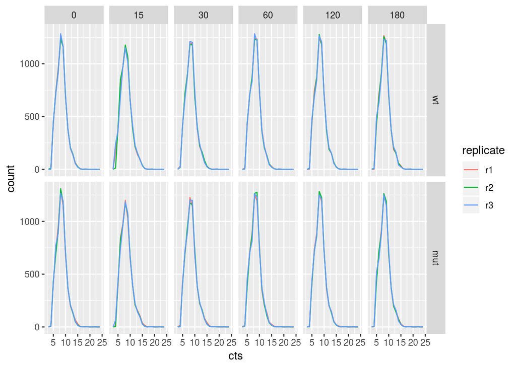

```r
norm_cts_long %>%
  ggplot(aes(cts, colour = replicate)) +
  geom_freqpoly(binwidth = 1) +
  facet_grid(strain ~ minute)
```

**Exercise:**

- Try out other ways to visualise these data, for example as a boxplot of expression data

# Exploring gene expression correlations between samples

Scatter plots are useful e.g. to visually inspect similarity (correlation) between variables.

For this type of plot, the “spread” version of our counts table is useful. For example, let’s look at the correlation between two replicates of WT at 0 min:

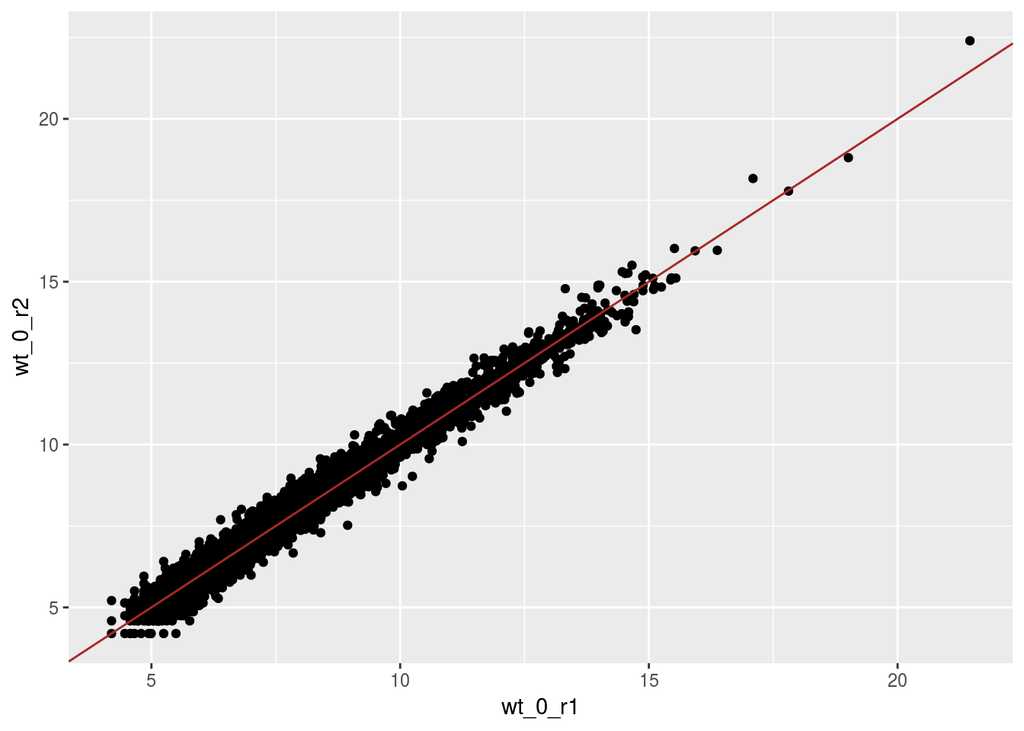

```r
norm_cts_tbl %>%
  ggplot(aes(wt_0_r1, wt_0_r2)) + geom_point() +
  geom_abline(colour = "brown")
```

As we can see, these are very tightly correlated, which might be expected given these are biological replicates of the same strain and treatment!

**Exercise:**

- Compare the expression between a WT cell at T0 and T30. What can you conclude from this?

Because we have so many samples, it would be nice to get an overview of the correlation across all samples. One way to do this is with a correlation plot. The `corrr` package provides with several convenience functions to calculate and visualise correlations. We won’t go into details in this lesson, but please check the [package’s documentation](https://cran.r-project.org/web/packages/corrr/vignettes/using-corrr.html). Here is a quick example:

```
##
## Correlation method: 'spearman'
## Missing treated using: 'pairwise.complete.obs'
```

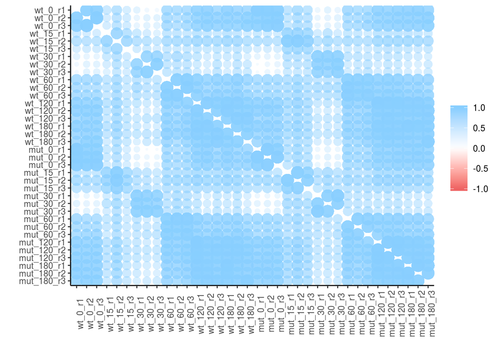

```r
library(corrr)
correlate(norm_cts, method = "spearman") %>%
  rplot() +
  theme(axis.text.x = element_text(angle = 90))
```

# Explore properties of the data normalization applied

So far we have looked at RNA-Seq data that has been preprocessed for us (`norm_cts`) using a sophisticated method (`DESeq2`).

In the following, we will also take a look at the raw data (`raw_cts`) and compare these to the normalized version to explore some properties of the data normalization applied.

Make sure that you have a “tidy” version of these raw counts:

```r
raw_cts_tbl <- as_tibble(raw_cts, rownames = "gene")
raw_cts_long <- raw_cts_tbl %>%
  gather(sample, cts, -gene)
```

The summary function is quite handy here as a first approach to exploring differences between raw and normalized counts.

```r
summary(raw_cts_long$cts)
```

```
##    Min. 1st Qu.  Median    Mean 3rd Qu.    Max.
##       0      87     274    2042     704 8758155
```

```r
summary(norm_cts_long$cts)
```

```
##    Min. 1st Qu.  Median    Mean 3rd Qu.    Max.
##   4.198   6.915   8.273   8.369   9.532  23.062
```

Raw and normalized data live on VERY different scales - the `raw_cts_long` has a few very large count values while most values are comparatively small. Partially, this is because the normalised counts are on a log-scale. Let’s visualise the correlation between two samples like we did above, but for raw counts:

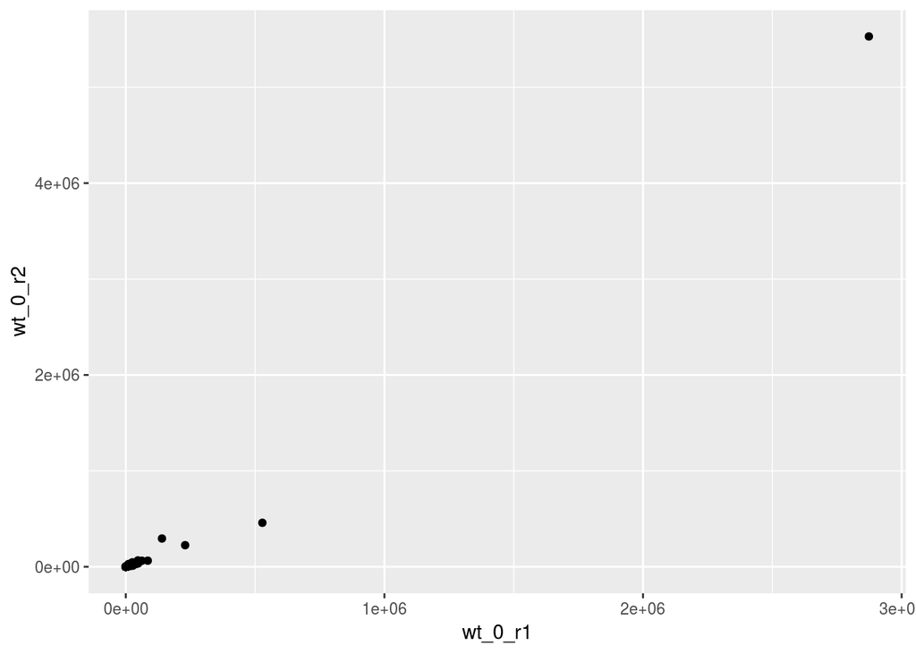

```r
raw_cts_tbl %>%
  ggplot(aes(wt_0_r1, wt_0_r2)) +
  geom_point()
```

As you see, the range of values is very large and we can hardly see the relationship between these counts. You can change the axis scales of the plot:

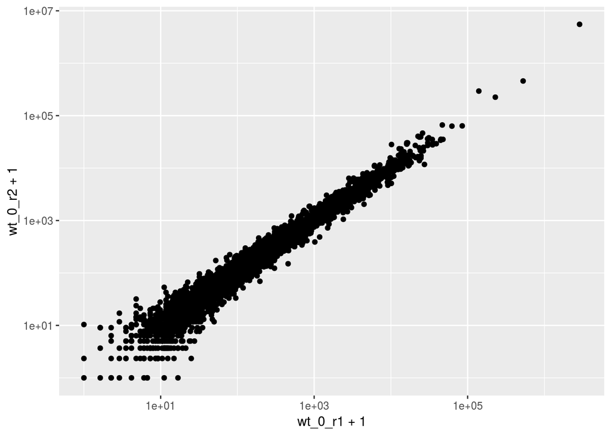

```r
raw_cts_tbl %>%
  ggplot(aes(wt_0_r1 + 1, wt_0_r2 + 1)) +
  geom_point() +
  scale_x_log10() + scale_y_log10()
```

From this, we can already see that the raw data seem more variable (especially for low values) than the normalised data. Let’s examine the relationship between mean and variance of each gene across all samples:

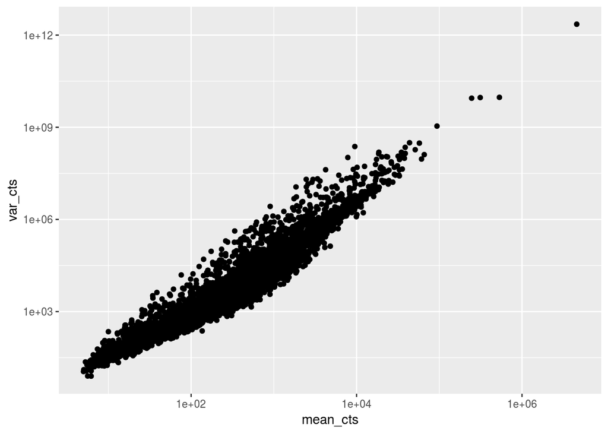

```r
raw_cts_long %>%
  group_by(gene) %>%
  summarise(mean_cts = mean(cts),
            var_cts = var(cts)) %>%
  ggplot(aes(mean_cts, var_cts)) +
  geom_point() +
  scale_x_log10() + scale_y_log10()
```

This positive relationship between mean and variance is very typical of count data, and this is why you need to be careful to apply specialised statistical methods (such as those provided by `DESeq2`) that model these properties of the data.

Compare this with the normalised data:

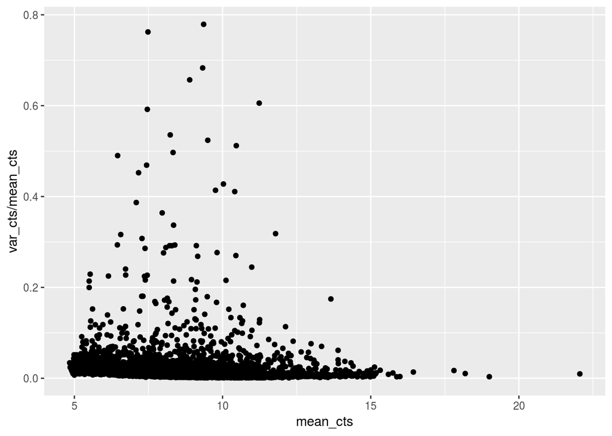

```r
norm_cts_long %>%
  group_by(gene) %>%
  summarise(mean_cts = mean(cts),
            var_cts = var(cts)) %>%
  ggplot(aes(mean_cts, var_cts/mean_cts)) +
  geom_point()
```

In conclusion, these mean-variance plots verify that `DESeq2`’s normalization approach is effectively achieving its main goal: to stabilize the variance, as the normalised data do no longer show a (strong) dependency between a gene’s mean and its variance.

# Exploring the effects of genotype and stress on the transcritpome

Having expression data for thousands of genes can be overwhelming to explore! This is a good example of a multi-dimensional dataset. Here, we have many variables (genes) that we want to use to understand our samples (yeast cells).

There are several methods to help in summarising multi-dimensional data, here we will show how to use PCA (principal component analysis).

PCA is a transformation of high-dimensional data into an orthogonal basis such that first principal component (PC, aka “axis”“) is aligned with the largest source of variance, the second PC to the largest remaining source of variance and so on. This makes high-dimensional data more amenable to visual exploration, as we can examine projections to the first two (or few) PCs.

To compute a PCA in R we can use the `prcomp()` function. This function can take a matrix of data, where the *columns* are the variables that we want to use to transform our *samples*, which shoul be the *rows* of the matrix.

In our case, we want to look for similarities across our yeast cells (*samples* = *rows*) based on gene expression (*variables* = *columns*). For that reason, we need to provide a *transposed* version of our table to the `prcomp()` function:

```r
sample_pca <- prcomp(t(norm_cts))
```

The output from this command contains several pieces of information, namely: * eigenvectors * eigenvalues * PC scores

We can access these pieces of data using convenient functions from the `broom` package:

```r
library(broom)
tidy(sample_pca, matrix = "samples")    # PC scores for our yeast samples
```

```
## # A tibble: 1,296 x 3
##    row         PC  value
##    <fct>    <dbl>  <dbl>
##  1 wt_0_r1      1 -21.5
##  2 wt_0_r2      1 -20.9
##  3 wt_0_r3      1 -20.8
##  4 wt_15_r1     1  12.2
##  5 wt_15_r2     1  11.0
##  6 wt_15_r3     1  14.5
##  7 wt_30_r1     1  33.1
##  8 wt_30_r2     1  35.7
##  9 wt_30_r3     1  33.2
## 10 wt_60_r1     1  -1.87
## # ... with 1,286 more rows
```

```r
tidy(sample_pca, matrix = "variables")  # variable loadings (eigen vectors) for genes that were used as variables in PCA
```

```
## # A tibble: 216,396 x 3
##    column         PC    value
##    <chr>       <dbl>    <dbl>
##  1 SPAC212.11      1  0.00653
##  2 SPAC212.09c     1  0.00915
##  3 SPAC212.04c     1  0.0125
##  4 SPNCRNA.601     1 -0.00461
##  5 SPAC977.11      1 -0.00176
##  6 SPAC977.13c     1  0.0342
##  7 SPAC977.15      1  0.0126
##  8 SPAC977.16c     1  0.0102
##  9 SPNCRNA.607     1  0.0221
## 10 SPAC1F8.06      1 -0.0159
## # ... with 216,386 more rows
```

```r
tidy(sample_pca, matrix = "pcs")        # PC variances (eigen values)
```

```
## # A tibble: 36 x 4
##       PC std.dev percent cumulative
##    <dbl>   <dbl>   <dbl>      <dbl>
##  1     1   18.7   0.388       0.388
##  2     2   12.1   0.163       0.552
##  3     3    8.76  0.0850      0.637
##  4     4    7.15  0.0567      0.693
##  5     5    6.99  0.0541      0.747
##  6     6    5.43  0.0326      0.780
##  7     7    5.20  0.0299      0.810
##  8     8    4.10  0.0186      0.828
##  9     9    3.79  0.0159      0.844
## 10    10    3.67  0.0149      0.859
## # ... with 26 more rows
```

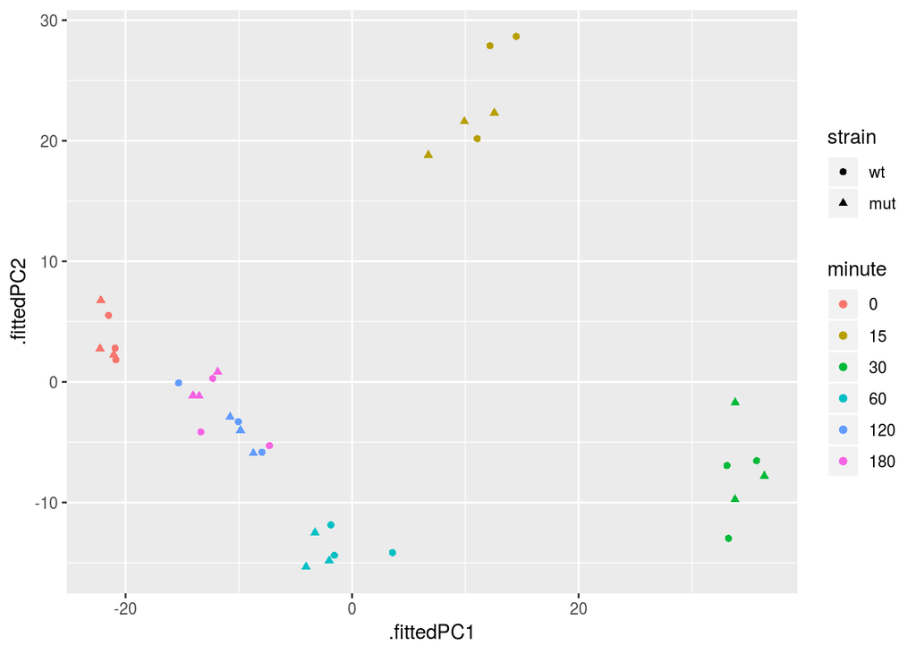

```r
augment(sample_pca) %>%
  full_join(sample_info, by = c(".rownames" = "sample")) %>%
  ggplot(aes(.fittedPC1, .fittedPC2)) +
  geom_point(aes(colour = minute, shape = strain))
```

We can see the proportion of variance explained by each PC axis:

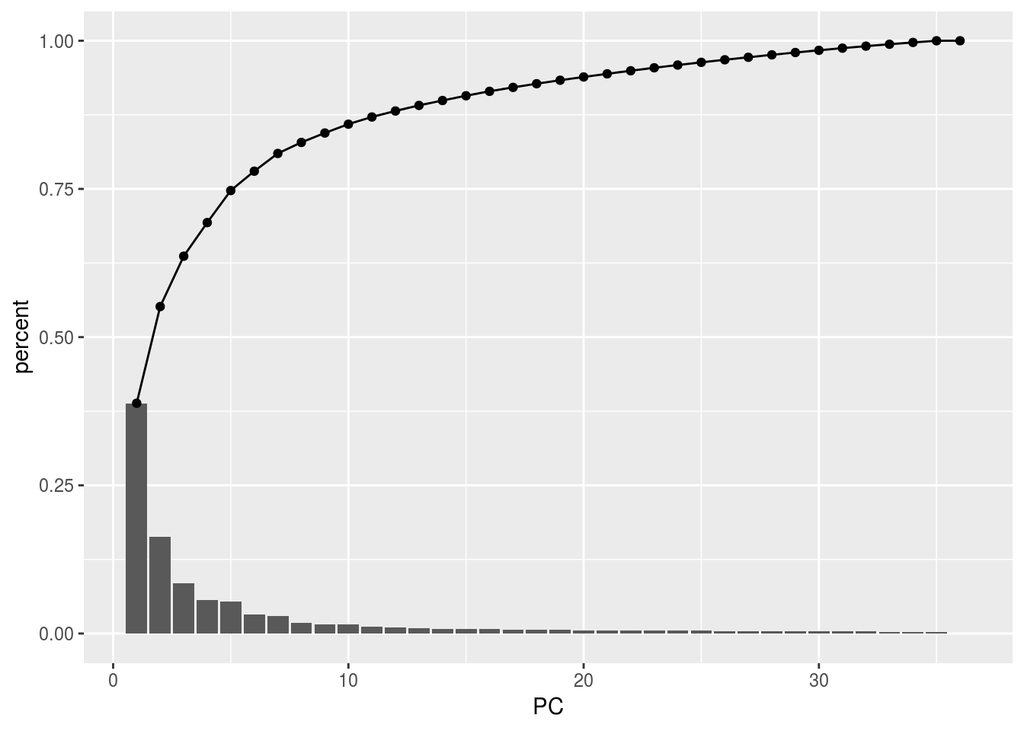

```r
broom::tidy(sample_pca, matrix = "pcs") %>%
  ggplot(aes(PC, percent)) +
  geom_col() +
  geom_line(aes(y = cumulative)) + geom_point(aes(y = cumulative))
```

And we can also look at the “influence” that each of the genes has on our PC axis. This is given by the eigen vectors (the squared value of eigen vector gives you the correlation between the PC axis and the respective variable).

This plot is a bit more challenging to do, because we have so many genes! Here’s one possibility:

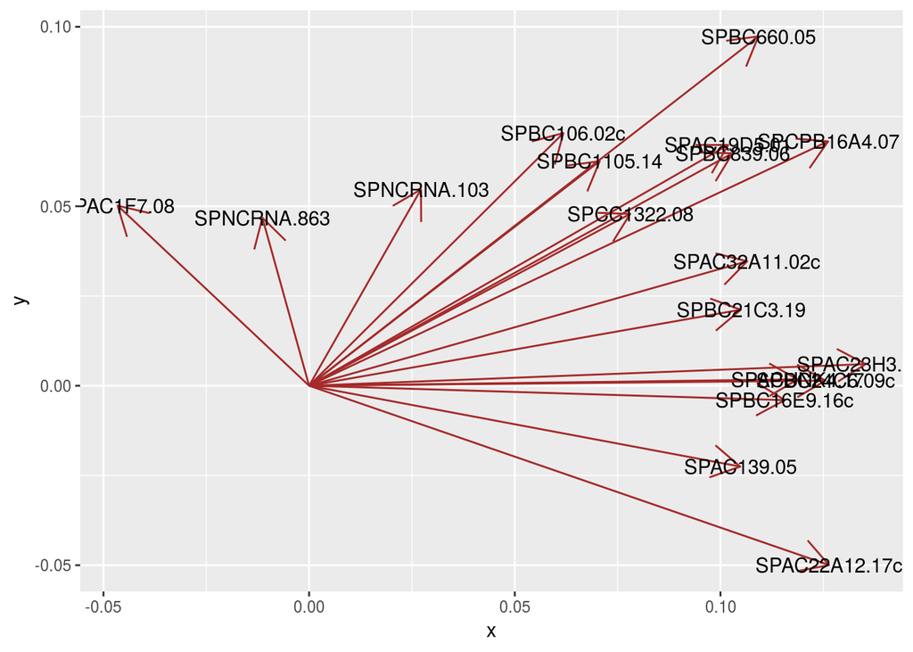

```r
# Extract genes with highest loadings on PC1 and PC2
top_genes <- tidy(sample_pca, matrix = "variables") %>%  # get table of eigen vectors
  filter(PC %in% 1:2) %>%                   # retain only PC1 and PC2
  group_by(PC) %>%                          # for each PC
  arrange(desc(value)) %>%                  # sort table by descending value
  slice(1:10) %>%                           # take top 10 rows of each PC group
  pull(column) %>%                          # extract the column (gene name) from the table
  unique()                                  # retain unique gene names only

# Plot eigen vectors for these genes
tidy(sample_pca, matrix = "variables") %>%  # get table of eigen vectors
  filter(column %in% top_genes & PC %in% 1:2) %>%  # retain only genes and PCs of interest
  mutate(PC = paste0("PC", PC)) %>%                # add "PC" suffix to this variable
  spread(PC, value) %>%
  ggplot() +
  geom_segment(aes(x = 0, y = 0, xend = PC1, yend = PC2), arrow = arrow(),
               colour = "brown") +
  geom_text(aes(x = PC1, y = PC2, label = column))
```